# Zadania z laboratorium 7 i laboratorium 8

Wybrane pakiety do analizy danych 2024

Martyński Tomasz

2024-12-30

# Laboratorium 7 - niektóre zadania pominięte

Numeracja zadań jak w plikach z laboratoriami

## Zadanie 1.2 - Zadanie 1 - kongruencyjny generator liczb losowych

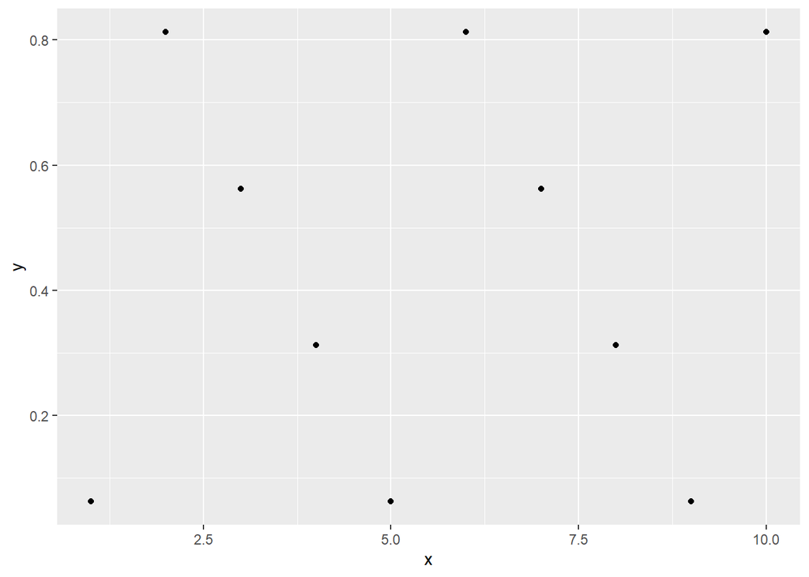

```r
lcm=function(N, x0, a, d, m){
  x=x0
  punkty=c(x)
  for(i in 1:(N-1)){
    x=((a*x+d)%%m)
    punkty=c(punkty,x)
  }
return(punkty/m)
}

N=10
y=lcm(N = 10, x0 = 4, a = 13, d = 0, m = 64)
library(ggplot2)
x=seq(1,N,by=1)
df=data.frame(x,y)
ggplot(df, aes(x,y))+
  geom_point()
```

Na podstawie wykresu można stwierdzić, że ten sposób generowania NIE jest “losowy” - widać wzór.

## Zadanie 1.3 - Zadanie 2 - kongruencyjny generator liczb losowych

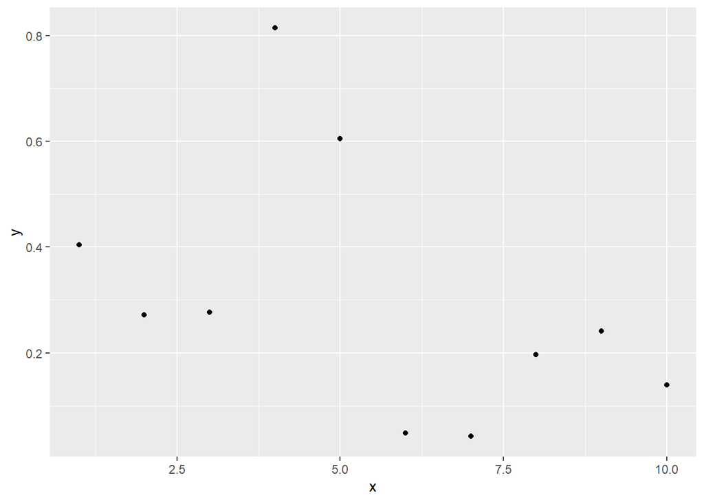

```r
y=lcm(N = 10, x0 = as.numeric(Sys.time()), a = 1103515245, d = 12345, m = 2 ** 32)

library(ggplot2)
x=seq(1,N,by=1)
df=data.frame(x,y)
ggplot(df, aes(x,y))+
  geom_point()
```

Tutaj już widać, że te punkty są generowane w sposób losowy, tzn. nie widać żadnego wzoru.

## Zadanie 2.2.1 - `unif` - 4 wykresy: gęstości i dystrybuanty

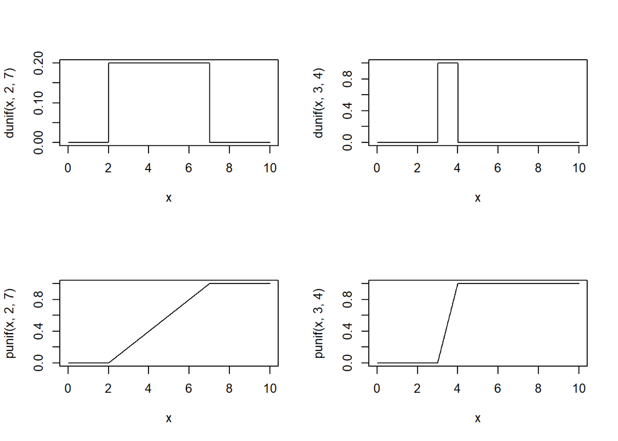

```r
par(mfrow=c(2,2))
x=seq(0,10,by=0.01)
plot(x,dunif(x,2,7), type='l')
plot(x,dunif(x,3,4), type='l')
plot(x,punif(x,2,7), type='l')
plot(x,punif(x,3,4), type='l')
```

## Zadanie 2.2.2 - `unif` - funkcja kwantylowa

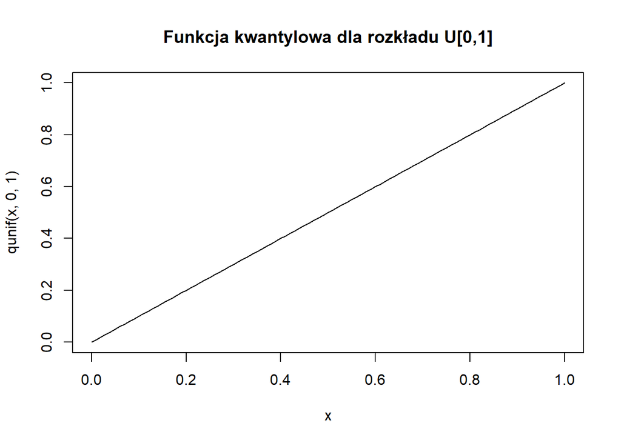

```r
x=seq(0,1,by=0.01)
plot(x, qunif(x,0,1),type='l', main='Funkcja kwantylowa dla rozkładu U[0,1]')
```

## Zadanie2.2.3 - `unif` - histogram i gęstość rozkładu

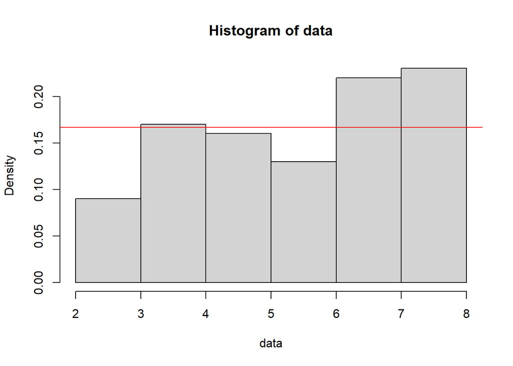

```r
data=runif(100,2,8)
hist(data, probability = TRUE)
abline(h=1/6, col="red")
```

## Zadanie 2.3.1 - metoda dystrybuanty odwrotnej + rozkład wykładniczy

```r
set.seed(202)
lambda=2
# F_x(x)=1-exp(-lambda*x)
# F^(-1)_x(u)=-1/lambda*log(1-u)

u=runif(5)
x=-1/lambda*log(1-u)
x
```

```
## [1] 0.06897777 0.55456051 0.20008199 0.11390671 0.22965812
```

## Zadanie 2.3.3 - metoda dystrybuanty odwrotnej - rozkład jednostajny

```r
set.seed(202)

#F_x(x)=(x-2)/4
#F^(-1)_x(u)=2+4u

u=runif(5)
x1=2+4*u
x1
```

```
## [1] 2.515450 4.680605 3.319159 2.814909 3.473138
```

```r
x2=runif(5,2,6)
x2
```

```
## [1] 5.129214 2.793936 2.876312 3.767799 4.569107
```

## Zadanie 2.4.1.2 - symulacja egzaminu

```r
#1.

wyniki=rnorm(200, mean=72, sd=15.2)
wyniki
```

```
##   [1]  50.25565  60.19567  42.61365  76.75830  79.12351  69.89571  89.93421
##   [8]  60.20658  70.37351  97.37899  68.07501 102.01275  63.46822  86.55198
##  [15]  93.96531  77.15959  85.39047  85.73377  83.39891  77.45745  75.83894
##  [22]  80.77414  78.35892  61.95166 113.74274  98.86886  86.34448  60.05665
##  [29]  50.54874  66.54444  79.53787  58.94755  79.78923  45.40370  60.75870
##  [36]  99.90697  81.07346  70.34591  79.85413  88.51572  77.04106 100.16503
##  [43]  54.96353  75.82624  61.93120  58.36913  90.42027  72.29841 105.90387
##  [50]  79.72224  82.76675  73.36922  74.10100  79.07150  70.36899  87.51090
##  [57]  85.96696  73.27398  44.37411  73.14280  68.53527  75.46870  57.14019
##  [64]  65.45718  85.77952  75.60814  61.58882  72.43440  70.62285  70.48797
##  [71]  62.98982  55.46135  36.15216  41.51459  70.55789  70.68187  86.58826
##  [78]  67.61372  69.51629  40.09995  89.19534  92.11130  74.04269  80.83864
##  [85]  63.92431  57.02712  81.12897  97.34938  56.76603  75.20152  63.76501
##  [92]  87.42350  78.88525  68.86505  90.54188  57.08597  71.47586  57.94125
##  [99]  71.37002  66.90118  52.27214 109.14732  70.02810  83.15552  64.37385
## [106]  58.54846  36.46418  64.60342  91.40260  95.11624  69.11783  64.93542
## [113]  84.70707  50.88530  46.47389  75.41818  83.52936  59.22399  51.79782
## [120]  63.63641  84.63869  69.31509  81.38250  90.40599  85.56938  53.27437
## [127]  63.91994  62.49411  68.43218  77.30436  89.30906  76.09300  69.26899
## [134]  70.56125  92.10744  91.76387  52.14118  86.77979  70.85060  95.51296
## [141]  85.70121  68.67430  71.99423  70.28760  80.44130  63.19580  86.22078
## [148]  83.49388 102.20670  72.43489  91.66611  66.42915  95.11189  87.30146
## [155]  39.06307  91.27355  76.55620  82.10441  98.13108  78.27004  84.18164
## [162]  44.19918  74.85626  61.65678  62.64124  66.95388  78.81278  51.13668
## [169]  58.05118  91.07849  67.80044  70.25119  50.73784 105.27229  66.20539
## [176]  83.16635  54.56151  76.81589  86.63174  67.69614  42.46642  83.26943
## [183]  62.73479  80.94892  67.10142  78.84055  96.45704  62.15171  67.22504
## [190]  79.71056  85.33057  74.49903  88.00321  77.77358  45.30389  79.74646
## [197]  76.08040  91.85766  92.39816 104.79165
```

```r
#2.
#P(x>=84)=1-P(x<=84)=1-F_x(84)
P_84_or_more=1-pnorm(84, mean=72, sd=15.2)
P_84_or_more
```

```
## [1] 0.2149176
```

## Zadanie 2.4.1.3 - 3 odchylenia standardowe

```r
# P(mi-3sigma<x<mi+3sigma)=F(mi+3sigma)-F(mi-3sigma)
mi=0.5
sigma=2 #sqrt(4)

pnorm(mi+3*sigma, mean=mi, sd=sigma)-pnorm(mi-3*sigma, mean=mi, sd=sigma)
```

```
## [1] 0.9973002
```

## Zadanie 2.6.1.1 - wykresy rozkładu t-Studenta

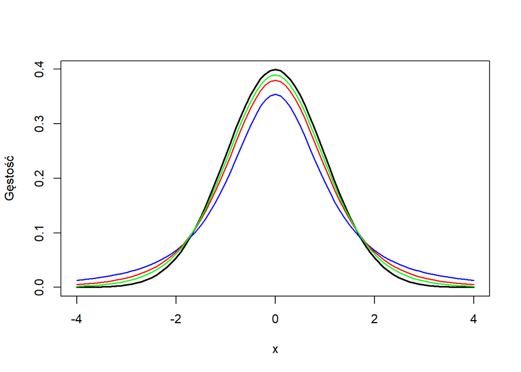

```r
x=seq(-4,4,0.1)
plot(x, dnorm(x), type="l", ylab="Gęstość", lwd=2)

y1=dt(x, 2)
y2=dt(x, 5)
y3=dt(x, 10)

lines(x, y1, type="l", col="blue", lwd=1.5)
lines(x, y2, type="l", col="red", lwd=1.5)
lines(x, y3, type="l", col="green", lwd=1.5)
```

## Zadanie 2.6.1.2 - statystyka t

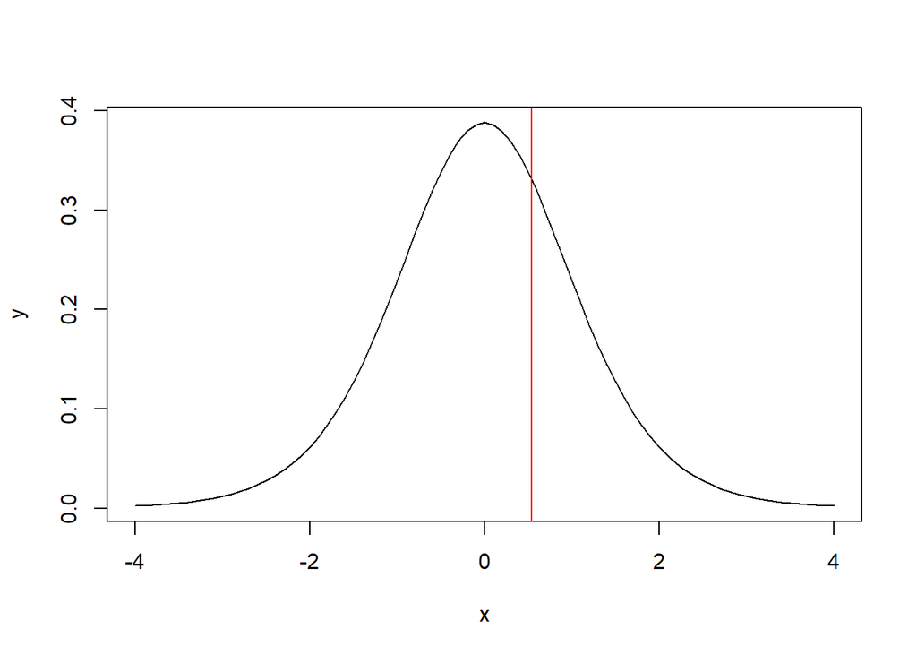

```r
obserwacje=rnorm(10, mean=0.5, sd=sqrt(2))
srednia=mean(obserwacje)
odch=sd(obserwacje)

t=(srednia-0.5)/(odch/sqrt(10))

x=seq(-4,4,0.1)
y=dt(x,9)
plot(x, y, type="l", col="black")
abline(v=t, col="red")
```

## Zadanie 2.8.1.1 - quiz z angielskiego

```r
pbinom(4, 12, prob=0.2)
```

```
## [1] 0.9274445
```

## Zadanie 4.1 - analiza danych

```r
library(fitdistrplus)
library("Przewodnik")
dane=daneSoc
summary(dane)
```

```
##       wiek          wyksztalcenie     st.cywilny         plec
##  Min.   :22.00   podstawowe:93    singiel  :120   kobieta  : 55
##  1st Qu.:30.00   srednie   :55    w zwiazku: 84   mezczyzna:149
##  Median :45.00   wyzsze    :34
##  Mean   :43.16   zawodowe  :22
##  3rd Qu.:53.00
##  Max.   :75.00
##                praca     cisnienie.skurczowe cisnienie.rozkurczowe
##  nie pracuje      : 52   Min.   : 93.0       Min.   : 57.00
##  uczen lub pracuje:152   1st Qu.:126.0       1st Qu.: 77.00
##                          Median :137.5       Median : 80.00
##                          Mean   :137.0       Mean   : 80.43
##                          3rd Qu.:148.0       3rd Qu.: 86.25
##                          Max.   :178.0       Max.   :107.00
```

Ciśnienie skurczowe:

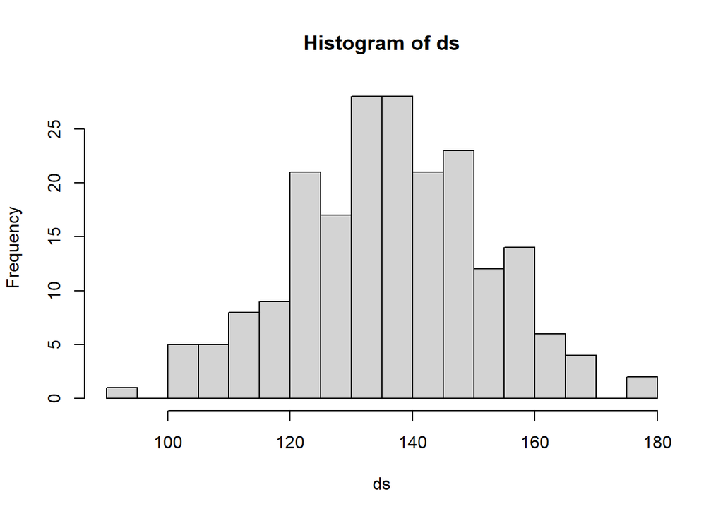

```r
ds=dane$cisnienie.skurczowe
#wypróbować rozkład normalny `norm`

hist(ds, breaks = 30)
```

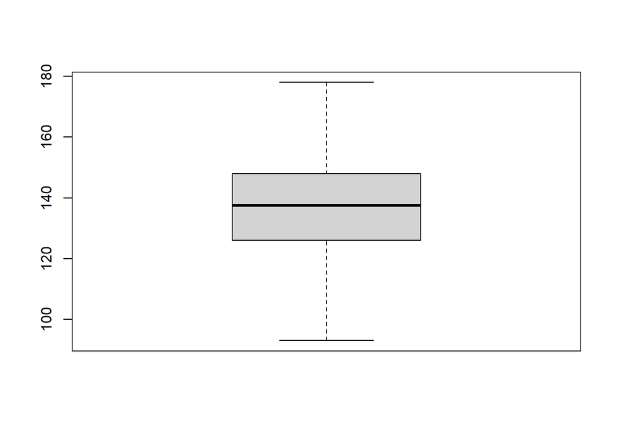

```r
boxplot(ds)
```

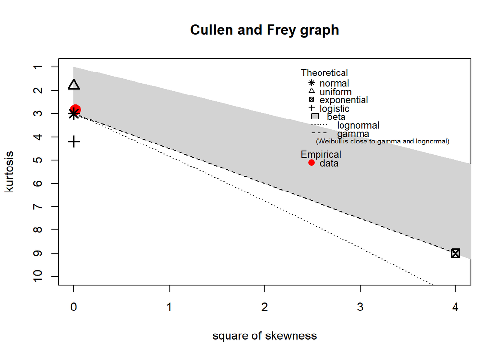

```
## summary statistics
## ------
## min:  93   max:  178
## median:  137.5
## mean:  136.951
## estimated sd:  15.71318
## estimated skewness:  -0.1186171
## estimated kurtosis:  2.829396
```

```r
descdist(ds, discrete = FALSE)
```

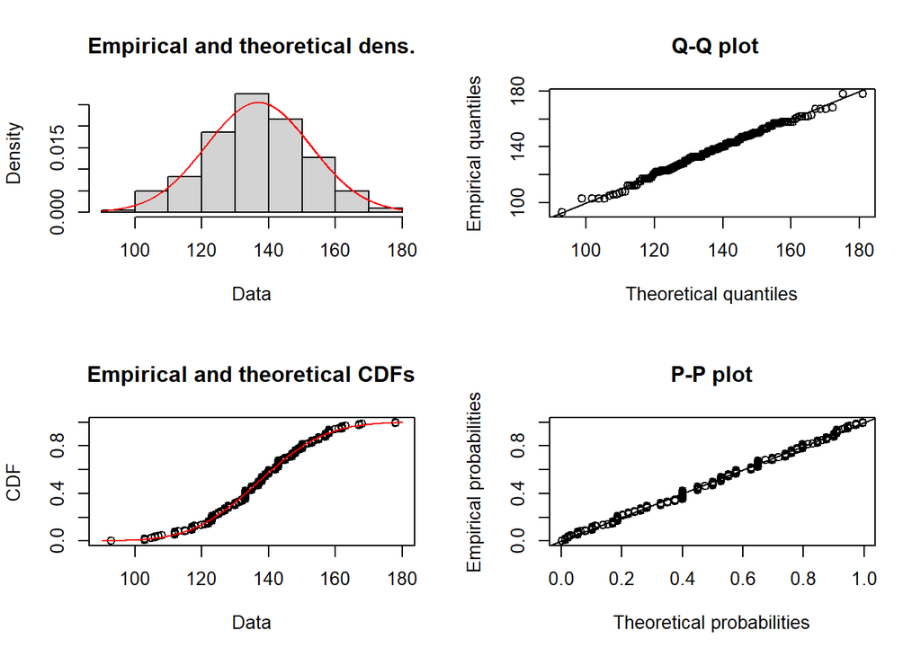

```r
fit_ds_norm=fitdist(ds, "norm")
plot(fit_ds_norm)
```

```r
gof_results = gofstat(fit_ds_norm, fitnames = c("Normalny"))
print(gof_results)
```

```
## Goodness-of-fit statistics
##                                Normalny
## Kolmogorov-Smirnov statistic 0.04755528
## Cramer-von Mises statistic   0.04564054
## Anderson-Darling statistic   0.32814592
##
## Goodness-of-fit criteria
##                                Normalny
## Akaike's Information Criterion 1705.760
## Bayesian Information Criterion 1712.397
```

Ciśnienie rozkurczowe:

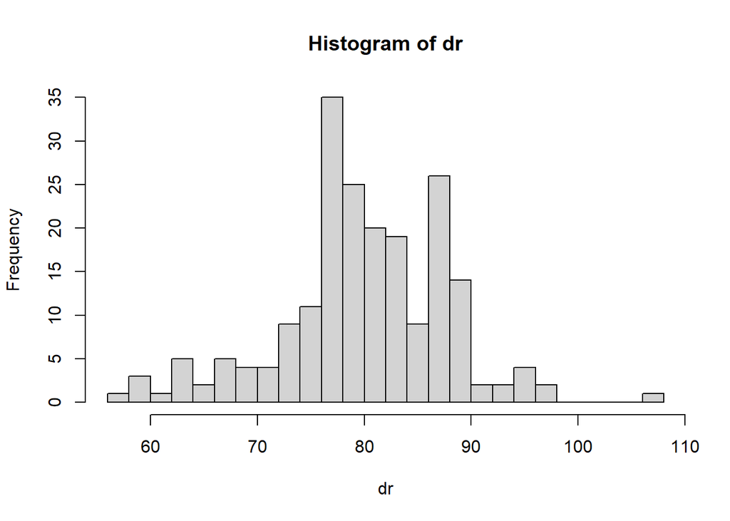

```r
dr=dane$cisnienie.rozkurczowe
#wypróbować rozkład logistyczni `logis` oraz normalny `norm`

hist(dr, breaks = 30)
```

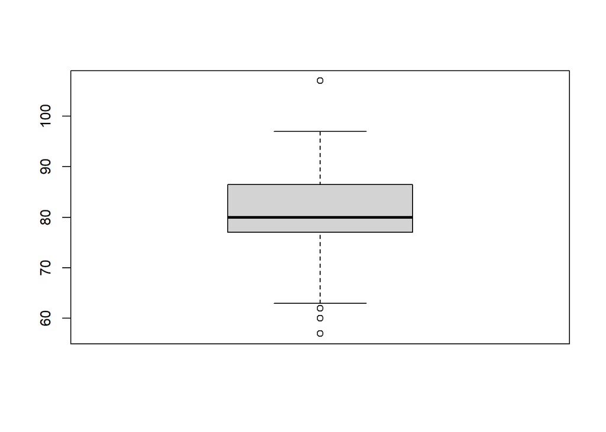

```r
boxplot(dr)
```

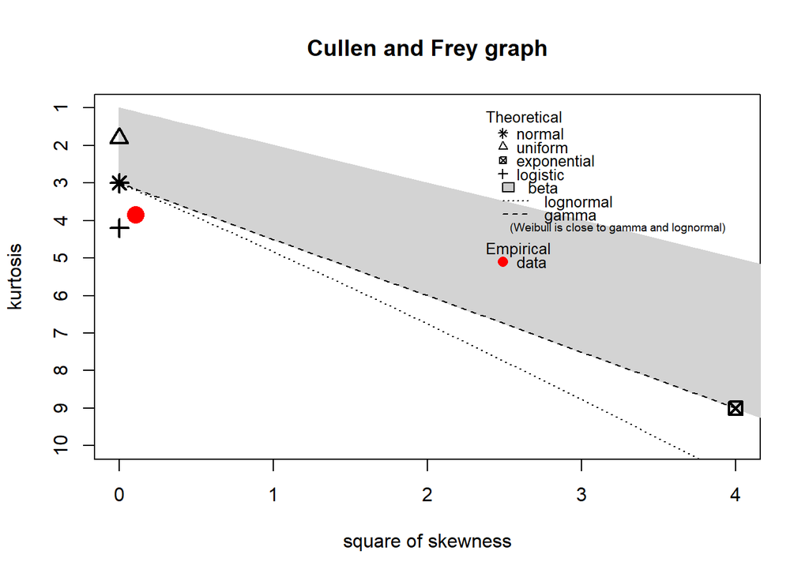

```
## summary statistics
## ------
## min:  57   max:  107
## median:  80
## mean:  80.42647
## estimated sd:  7.766892
## estimated skewness:  -0.3237879
## estimated kurtosis:  3.839672
```

```r
descdist(dr, discrete = FALSE)
```

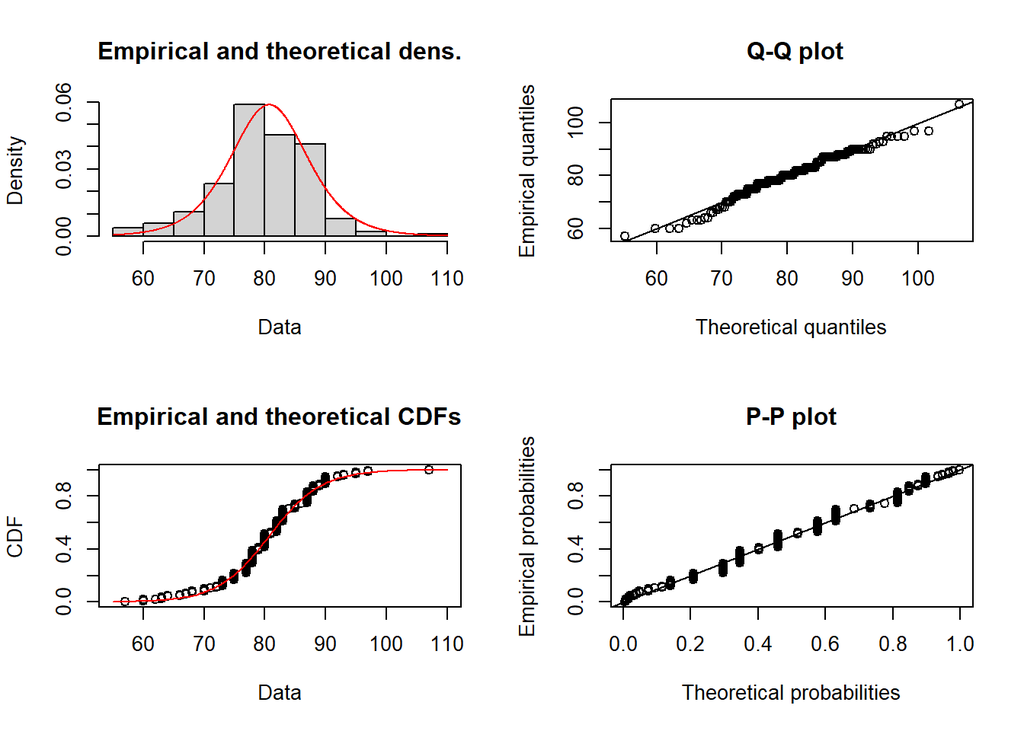

```r
fit_dr_logis=fitdist(dr, "logis")
plot(fit_dr_logis)
```

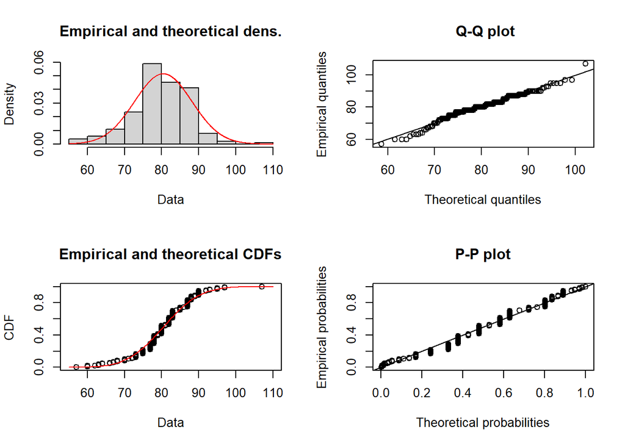

```r
fit_dr_norm=fitdist(dr, "norm")
plot(fit_dr_norm)
```

```r
gof_results = gofstat(list(fit_dr_logis, fit_dr_norm), fitnames = c("Logistyczny", "Normalny"))
print(gof_results)
```

```
## Goodness-of-fit statistics
##                              Logistyczny  Normalny
## Kolmogorov-Smirnov statistic  0.07502645 0.1085663
## Cramer-von Mises statistic    0.14599697 0.2606688
## Anderson-Darling statistic    1.01235553 1.6227785
##
## Goodness-of-fit criteria
##                                Logistyczny Normalny
## Akaike's Information Criterion    1412.366 1418.271
## Bayesian Information Criterion    1419.002 1424.908
```

Wiek:

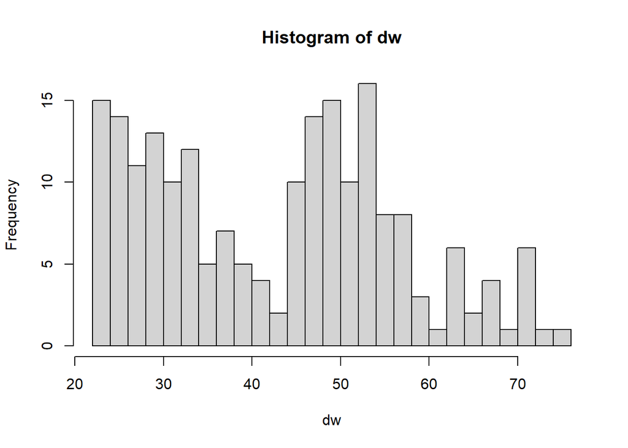

```r
dw=dane$wiek
#wypróbować rozkład beta `beta` oraz jednostajny `unif`

hist(dw, breaks = 30)
```

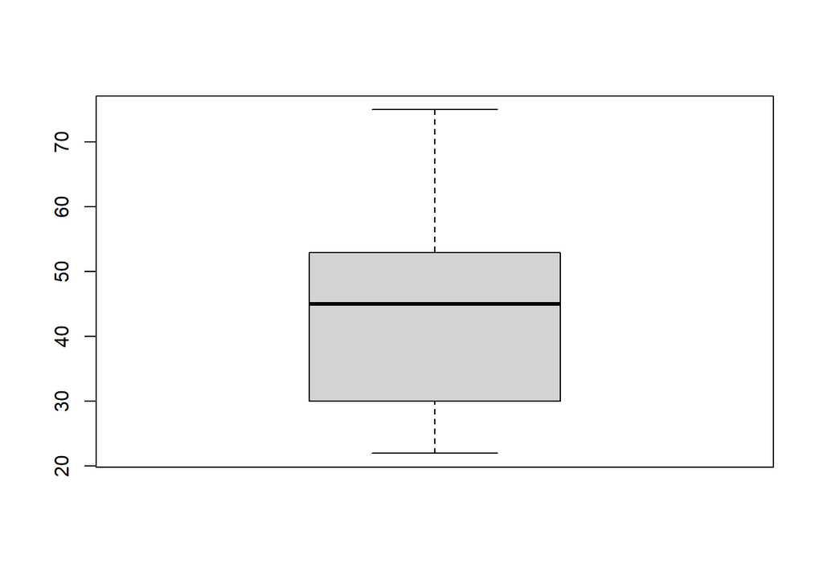

```r
boxplot(dw)
```

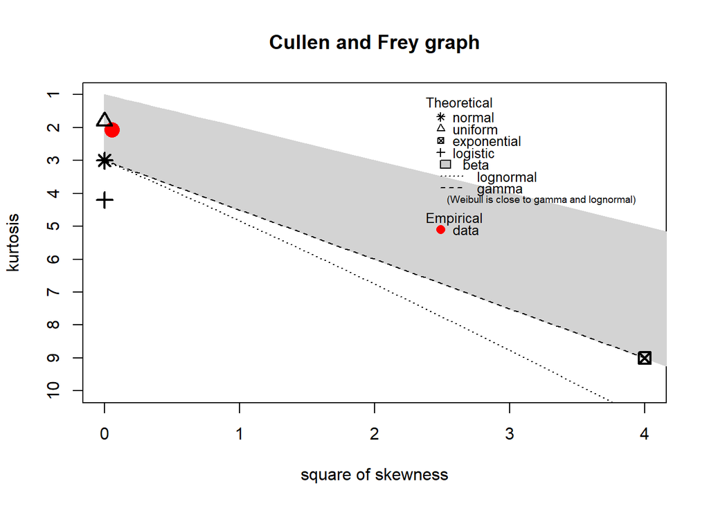

```
## summary statistics
## ------
## min:  22   max:  75
## median:  45
## mean:  43.16176
## estimated sd:  13.8471
## estimated skewness:  0.2366193
## estimated kurtosis:  2.070995
```

```r
descdist(dw, discrete = FALSE)
```

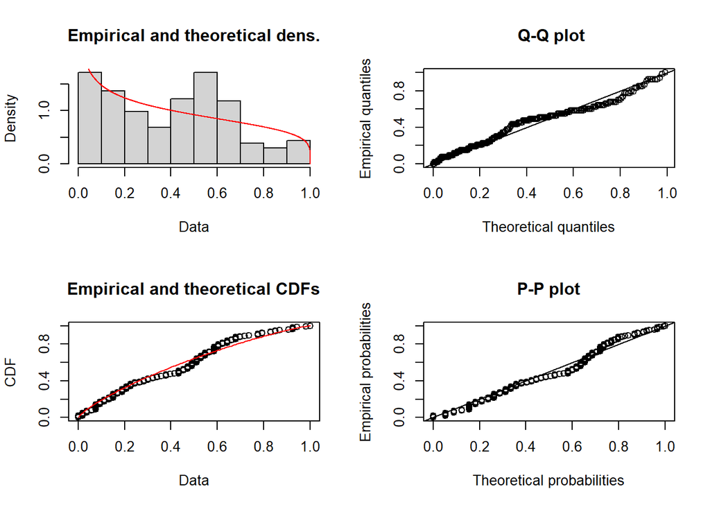

```r
normalize=function(x) {
  return((x - min(x)) / (max(x) - min(x)))
}

#Normalizacja na przedział (0,1)
normalized_dw=normalize(dw)
normalized_dw[normalized_dw==0]=0.00001
normalized_dw[normalized_dw==1]=0.99999

fit_dw_beta=fitdist(normalized_dw, "beta")
plot(fit_dw_beta)
```

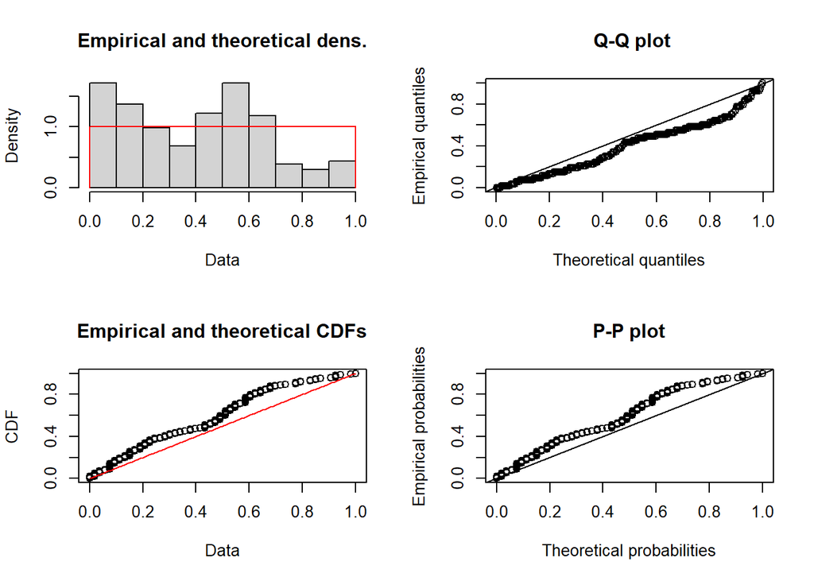

```r
fit_dw_unif=fitdist(normalized_dw, "unif")
plot(fit_dw_unif)
```

```r
gof_results=gofstat(list(fit_dw_beta, fit_dw_unif), fitnames = c("Beta", "Jednostajny"))
print(gof_results)
```

```
## Goodness-of-fit statistics
##                                   Beta Jednostajny
## Kolmogorov-Smirnov statistic 0.1012414   0.1982021
## Cramer-von Mises statistic   0.3577842   2.5762635
## Anderson-Darling statistic   2.3504243         Inf
##
## Goodness-of-fit criteria
##                                     Beta Jednostajny
## Akaike's Information Criterion -27.90943     3.99184
## Bayesian Information Criterion -21.27319    10.62808
```

Wnioski: testy AIC i BIC oraz statystyki pokazują, że rozkład beta przybliża dane lepiej, niż rozkład jednostajny. Nie sposób nie zwrócić uwagi na to, że w statystyce Andersona-Darlinga dla rozkładu jednostajnego otrzymujemy wartość Inf, co sugeruje potencjalnie bardzo dużą niedokładność.

# Laboratorium 8

## Zadanie 1.2.6 - regresja liniowa

```r
library(faraway)
data(gala)

#a)
model=lm(gala$Species~gala$Endemics+gala$Area+gala$Elevation+gala$Nearest+gala$Scruz+gala$Adjacent)
summary(model)
```

```
##
## Call:
## lm(formula = gala$Species ~ gala$Endemics + gala$Area + gala$Elevation +
##     gala$Nearest + gala$Scruz + gala$Adjacent)
##
## Residuals:
##     Min      1Q  Median      3Q     Max
## -68.219 -10.225   1.830   9.557  71.090
##
## Coefficients:
##                  Estimate Std. Error t value Pr(>|t|)
## (Intercept)    -15.337942   9.423550  -1.628    0.117
## gala$Endemics    4.393654   0.481203   9.131 4.13e-09 ***
## gala$Area        0.013258   0.011403   1.163    0.257
## gala$Elevation  -0.047537   0.047596  -0.999    0.328
## gala$Nearest    -0.101460   0.500871  -0.203    0.841
## gala$Scruz       0.008256   0.105884   0.078    0.939
## gala$Adjacent    0.001811   0.011879   0.152    0.880
## ---
## Signif. codes:  0 '***' 0.001 '**' 0.01 '*' 0.05 '.' 0.1 ' ' 1
##
## Residual standard error: 28.96 on 23 degrees of freedom
## Multiple R-squared:  0.9494, Adjusted R-squared:  0.9362
## F-statistic: 71.88 on 6 and 23 DF,  p-value: 9.674e-14
```

```r
#b)

X=cbind(1, gala$Endemics, gala$Area, gala$Elevation, gala$Nearest, gala$Scruz, gala$Adjacent)

Y=c(gala$Species)

coofs=solve(t(X) %*% X) %*% t(X) %*% Y
coofs
```

```
##               [,1]
## [1,] -15.337942100
## [2,]   4.393653649
## [3,]   0.013258111
## [4,]  -0.047537328
## [5,]  -0.101459511
## [6,]   0.008255847
## [7,]   0.001810681
```

Widać, że otrzymaliśmy takie same współczynniki, jak gdy korzystaliśmy z “summary”.

```r
#c)
sum_licznik=sum((Y-X%*%coofs)^2)
sum_mianownik=sum((Y-mean(Y))^2)

R2=1-sum_licznik/sum_mianownik
R2_adj=1-(1-R2)*(length(Y)-1)/(length(Y)-length(coofs))

R2
```

```
## [1] 0.9493685
```

```r
R2_adj
```

```
## [1] 0.9361603
```

Otrzymaliśmy ponownie takie same rezultaty, jak w a).

```r
#d)
model2=lm(gala$Species~gala$Endemics+gala$Area+gala$Elevation+gala$Nearest+gala$Scruz+gala$Adjacent-1)
summary(model2)
```

```
##
## Call:
## lm(formula = gala$Species ~ gala$Endemics + gala$Area + gala$Elevation +
##     gala$Nearest + gala$Scruz + gala$Adjacent - 1)
##
## Residuals:
##     Min      1Q  Median      3Q     Max
## -62.798 -20.289  -4.039   3.163  76.593
##
## Coefficients:
##                 Estimate Std. Error t value Pr(>|t|)
## gala$Endemics   4.189697   0.480298   8.723  6.6e-09 ***
## gala$Area       0.017006   0.011546   1.473    0.154
## gala$Elevation -0.053133   0.049076  -1.083    0.290
## gala$Nearest   -0.130216   0.517471  -0.252    0.803
## gala$Scruz     -0.057777   0.101108  -0.571    0.573
## gala$Adjacent   0.001601   0.012279   0.130    0.897
## ---
## Signif. codes:  0 '***' 0.001 '**' 0.01 '*' 0.05 '.' 0.1 ' ' 1
##
## Residual standard error: 29.94 on 24 degrees of freedom
## Multiple R-squared:  0.9641, Adjusted R-squared:  0.9551
## F-statistic: 107.4 on 6 and 24 DF,  p-value: 3.925e-16
```

Drugi model (d) jest prawdopodobnie dokładniejszy, gdyż jego wartości R<sup>2</sup> i R<sup>2</sup>adj są bliższe 1 niż pierwszego modelu (a). Warto zwrócić jednak uwagę na to, że ma on nieznacznie większy średni błąd prognozy.

```r
#e)
model3=lm(gala$Species~gala$Elevation+gala$Adjacent-1)
summary(model3)
```

```
##
## Call:
## lm(formula = gala$Species ~ gala$Elevation + gala$Adjacent -
##     1)
##
## Residuals:
##     Min      1Q  Median      3Q     Max
## -103.44  -33.22  -10.31   23.89  203.42
##
## Coefficients:
##                Estimate Std. Error t value Pr(>|t|)
## gala$Elevation  0.27849    0.02413  11.539 3.73e-12 ***
## gala$Adjacent  -0.06910    0.01505  -4.593 8.43e-05 ***
## ---
## Signif. codes:  0 '***' 0.001 '**' 0.01 '*' 0.05 '.' 0.1 ' ' 1
##
## Residual standard error: 59.77 on 28 degrees of freedom
## Multiple R-squared:  0.833,  Adjusted R-squared:  0.8211
## F-statistic: 69.83 on 2 and 28 DF,  p-value: 1.312e-11
```

Model trzeci (e) jest najbardziej niedokładny - najmniejsze wartości R<sup>2</sup> i R<sup>2</sup>adj oraz dwa razy większy średni błąd prognozy. Najlepszy zatem wydaje się model drugi (d).

## Zadanie 1.3.1 - wykresy diagnostyczne

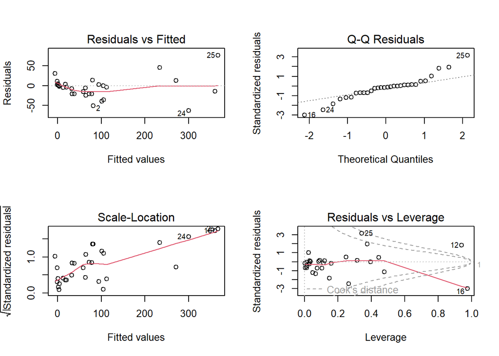

```r
#a)
par(mfrow=c(2,2))
plot(model2)
```

Wnioski z wykresów (kolejno):  
- widać zależność średniej od danych i oddalanie się od zera (to źle)  
- większość punktów układa się wokół prostej, która z pewnością nie jest równa y=x (to źle)  
- punkty nie są rozłożone równomiernie względem czerwonej linii (to źle)

Ten model absolutnie nie spełnia założeń.

```r
#b)
min_indeks=which.min(model2$residuals)
max_indeks=which.max(model2$residuals)

c(rownames(gala)[max_indeks], rownames(gala)[min_indeks])
```

```
## [1] "SantaCruz"   "SanSalvador"
```

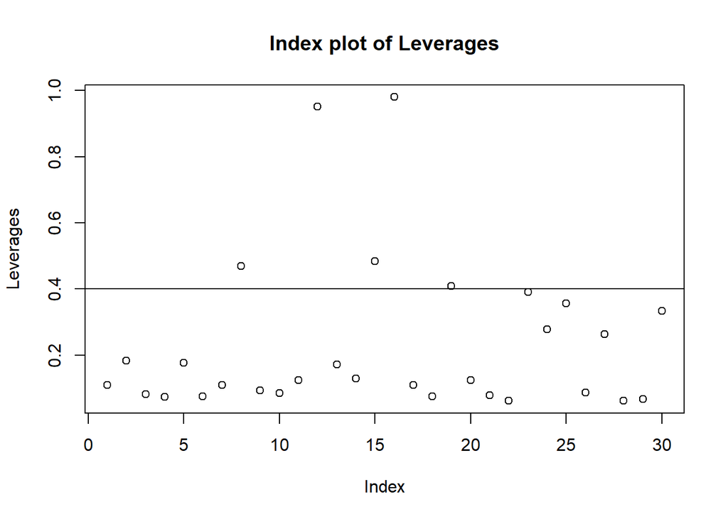

```r
#c)
X=model.matrix(model2)

plot(seq(1,30,1), hat(X), xlab="Index", ylab="Leverages", main="Index plot of Leverages")

linia_reg_kc=2*ncol(X)/nrow(X)
abline(h=linia_reg_kc)
```

```r
ind=which(hat(X)>linia_reg_kc)
gala[ind,]
```

```
##            Species Endemics    Area Elevation Nearest Scruz Adjacent
## Darwin          10        7    2.33       168    34.1 290.2     2.85
## Fernandina      93       35  634.49      1494     4.3  95.3  4669.32
## Genovesa        40       19   17.35        76    47.4  92.2   129.49
## Isabela        347       89 4669.32      1707     0.7  28.1   634.49
## Pinta          104       37   59.56       777    29.1 119.6   129.49
```

```r
gala2=gala[-ind,] #czystsze dane
gala2
```

```
##              Species Endemics   Area Elevation Nearest Scruz Adjacent
## Baltra            58       23  25.09       346     0.6   0.6     1.84
## Bartolome         31       21   1.24       109     0.6  26.3   572.33
## Caldwell           3        3   0.21       114     2.8  58.7     0.78
## Champion          25        9   0.10        46     1.9  47.4     0.18
## Coamano            2        1   0.05        77     1.9   1.9   903.82
## Daphne.Major      18       11   0.34       119     8.0   8.0     1.84
## Daphne.Minor      24        0   0.08        93     6.0  12.0     0.34
## Eden               8        4   0.03        71     0.4   0.4    17.95
## Enderby            2        2   0.18       112     2.6  50.2     0.10
## Espanola          97       26  58.27       198     1.1  88.3     0.57
## Gardner1          58       17   0.57        49     1.1  93.1    58.27
## Gardner2           5        4   0.78       227     4.6  62.2     0.21
## Marchena          51       23 129.49       343    29.1  85.9    59.56
## Onslow             2        2   0.01        25     3.3  45.9     0.10
## Pinzon           108       33  17.95       458    10.7  10.7     0.03
## Las.Plazas        12        9   0.23        94     0.5   0.6    25.09
## Rabida            70       30   4.89       367     4.4  24.4   572.33
## SanCristobal     280       65 551.62       716    45.2  66.6     0.57
## SanSalvador      237       81 572.33       906     0.2  19.8     4.89
## SantaCruz        444       95 903.82       864     0.6   0.0     0.52
## SantaFe           62       28  24.08       259    16.5  16.5     0.52
## SantaMaria       285       73 170.92       640     2.6  49.2     0.10
## Seymour           44       16   1.84       147     0.6   9.6    25.09
## Tortuga           16        8   1.24       186     6.8  50.9    17.95
## Wolf              21       12   2.85       253    34.1 254.7     2.33
```

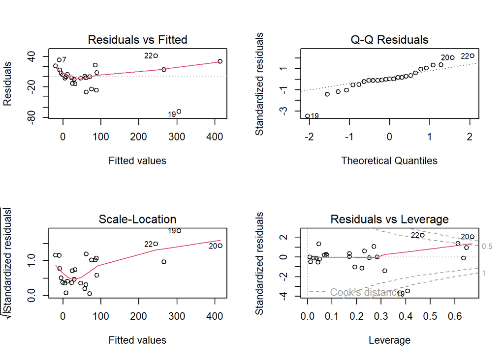

```r
model2_czysty=lm(gala2$Species~gala2$Endemics+gala2$Area+gala2$Elevation+gala2$Nearest+gala2$Scruz+gala2$Adjacent-1)

par(mfrow=c(2,2))
plot(model2_czysty)
```

Wydaje się, że usunięcie skrajnych obserwacji przyniosło pewien efekt, bo chociażby na pierszym wykresie widać, że czerwona linia jest bliżej zera i jest mniej “ciągnięta” przez dane. Nie jest jednak idealnie, chociażby na drugim wykresie prosta nadal sporo odbiega od y=x.

## Zadanie 2.3.1 - istotność współczynników

```r
summary(model)
```

```
##
## Call:
## lm(formula = gala$Species ~ gala$Endemics + gala$Area + gala$Elevation +
##     gala$Nearest + gala$Scruz + gala$Adjacent)
##
## Residuals:
##     Min      1Q  Median      3Q     Max
## -68.219 -10.225   1.830   9.557  71.090
##
## Coefficients:
##                  Estimate Std. Error t value Pr(>|t|)
## (Intercept)    -15.337942   9.423550  -1.628    0.117
## gala$Endemics    4.393654   0.481203   9.131 4.13e-09 ***
## gala$Area        0.013258   0.011403   1.163    0.257
## gala$Elevation  -0.047537   0.047596  -0.999    0.328
## gala$Nearest    -0.101460   0.500871  -0.203    0.841
## gala$Scruz       0.008256   0.105884   0.078    0.939
## gala$Adjacent    0.001811   0.011879   0.152    0.880
## ---
## Signif. codes:  0 '***' 0.001 '**' 0.01 '*' 0.05 '.' 0.1 ' ' 1
##
## Residual standard error: 28.96 on 23 degrees of freedom
## Multiple R-squared:  0.9494, Adjusted R-squared:  0.9362
## F-statistic: 71.88 on 6 and 23 DF,  p-value: 9.674e-14
```

Wyszedł tylko jeden istotny współczynnik, Endemics, oznaczony “***”.

## Zadanie 2.5 - testowanie założeń

```r
summary(model2)
```

```
##
## Call:
## lm(formula = gala$Species ~ gala$Endemics + gala$Area + gala$Elevation +
##     gala$Nearest + gala$Scruz + gala$Adjacent - 1)
##
## Residuals:
##     Min      1Q  Median      3Q     Max
## -62.798 -20.289  -4.039   3.163  76.593
##
## Coefficients:
##                 Estimate Std. Error t value Pr(>|t|)
## gala$Endemics   4.189697   0.480298   8.723  6.6e-09 ***
## gala$Area       0.017006   0.011546   1.473    0.154
## gala$Elevation -0.053133   0.049076  -1.083    0.290
## gala$Nearest   -0.130216   0.517471  -0.252    0.803
## gala$Scruz     -0.057777   0.101108  -0.571    0.573
## gala$Adjacent   0.001601   0.012279   0.130    0.897
## ---
## Signif. codes:  0 '***' 0.001 '**' 0.01 '*' 0.05 '.' 0.1 ' ' 1
##
## Residual standard error: 29.94 on 24 degrees of freedom
## Multiple R-squared:  0.9641, Adjusted R-squared:  0.9551
## F-statistic: 107.4 on 6 and 24 DF,  p-value: 3.925e-16
```

2. Niezależność obserwacji - obserwacje są niezależne (sprawdzamy rząd macierzy zrobionej z nich - wychodzi tyle, ile mamy kolumn => są one niezależne )

```r
macierz=cbind(gala$Endemics, gala$Area, gala$Elevation, gala$Nearest, gala$Scruz, gala$Adjacent)

qr(macierz)$rank
```

```
## [1] 6
```

3. Testowanie homoskedantyczności - test Breusch-Pagana: model jest okej np. dla alfa=0.001, aczkolwiek dla większych alf, jak 0.05, należy odrzucić hipotezę zerową, że wariancja jest jednorodna (to źle)

```r
library(lmtest)
bptest(model2)
```

```
##
##  studentized Breusch-Pagan test
##
## data:  model2
## BP = 15.292, df = 5, p-value = 0.009186
```

4. Niezależność reszt - test Durbin-Watsona: znowu, dla alfy=0.001 jest okej, ale dla większych już należy odrzucić hipotezę o tym, że są one niezależne (to źle)

```r
library("car")
durbinWatsonTest(model2)
```

```
##  lag Autocorrelation D-W Statistic p-value
##    1      -0.5118925      3.004144   0.006
##  Alternative hypothesis: rho != 0
```

5. Reszty a rozkład normalny - test Shapiro-Wilka: reszty mają rzeczywiście rozkład normalny, nawet dla alfa=0.05, gdyż p-value wyszło “całkiem duże”.

```r
shapiro.test(model2$residuals)
```

```
##
##  Shapiro-Wilk normality test
##
## data:  model2$residuals
## W = 0.9343, p-value = 0.06395
```

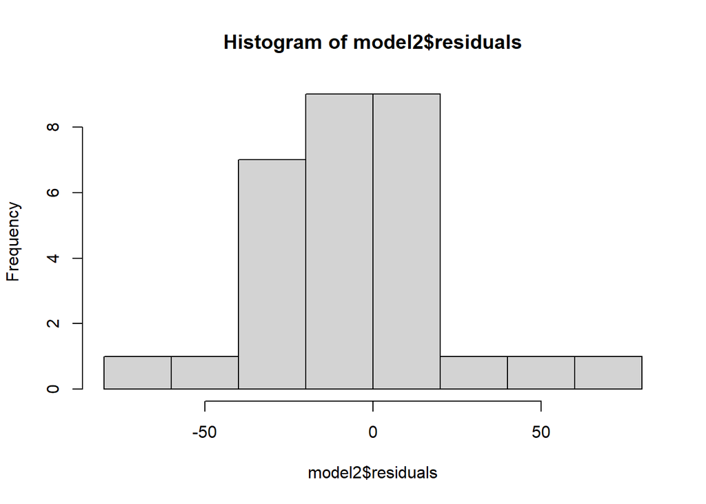

```r
hist(model2$residuals)
```

## Zadanie 2.6.1 - automatyczny wybór zmiennych

```r
model_f=step(lm(Species~., data=gala), direction="forward")
```

```
## Start:  AIC=207.99
## Species ~ Endemics + Area + Elevation + Nearest + Scruz + Adjacent
```

Istotne zmienne: Endemics, Area, Elevation, Nearest, Scruz, Adjacent.

```r
model_b=step(lm(Species~., data=gala), direction="backward")
```

```
## Start:  AIC=207.99
## Species ~ Endemics + Area + Elevation + Nearest + Scruz + Adjacent
##
##             Df Sum of Sq   RSS    AIC
## - Scruz      1         5 19300 206.00
## - Adjacent   1        19 19314 206.02
## - Nearest    1        34 19329 206.04
## - Elevation  1       837 20132 207.26
## - Area       1      1134 20429 207.71
## <none>                   19295 207.99
## - Endemics   1     69937 89231 251.93
##
## Step:  AIC=206
## Species ~ Endemics + Area + Elevation + Nearest + Adjacent
##
##             Df Sum of Sq   RSS    AIC
## - Adjacent   1        19 19318 204.03
## - Nearest    1        32 19332 204.05
## - Elevation  1       838 20138 205.28
## - Area       1      1129 20429 205.71
## <none>                   19300 206.00
## - Endemics   1     74567 93867 251.45
##
## Step:  AIC=204.03
## Species ~ Endemics + Area + Elevation + Nearest
##
##             Df Sum of Sq    RSS    AIC
## - Nearest    1        50  19369 202.11
## <none>                    19318 204.03
## - Area       1      1376  20694 204.09
## - Elevation  1      2232  21550 205.31
## - Endemics   1    150599 169918 267.26
##
## Step:  AIC=202.11
## Species ~ Endemics + Area + Elevation
##
##             Df Sum of Sq    RSS    AIC
## <none>                    19369 202.11
## - Area       1      1498  20866 202.34
## - Elevation  1      2287  21655 203.45
## - Endemics   1    150578 169947 265.26
```

Istotne zmienne: Endemics, Area, Elevation.

```r
model_fb=step(lm(Species~., data=gala), direction="both")
```

```
## Start:  AIC=207.99
## Species ~ Endemics + Area + Elevation + Nearest + Scruz + Adjacent
##
##             Df Sum of Sq   RSS    AIC
## - Scruz      1         5 19300 206.00
## - Adjacent   1        19 19314 206.02
## - Nearest    1        34 19329 206.04
## - Elevation  1       837 20132 207.26
## - Area       1      1134 20429 207.71
## <none>                   19295 207.99
## - Endemics   1     69937 89231 251.93
##
## Step:  AIC=206
## Species ~ Endemics + Area + Elevation + Nearest + Adjacent
##
##             Df Sum of Sq   RSS    AIC
## - Adjacent   1        19 19318 204.03
## - Nearest    1        32 19332 204.05
## - Elevation  1       838 20138 205.28
## - Area       1      1129 20429 205.71
## <none>                   19300 206.00
## + Scruz      1         5 19295 207.99
## - Endemics   1     74567 93867 251.45
##
## Step:  AIC=204.03
## Species ~ Endemics + Area + Elevation + Nearest
##
##             Df Sum of Sq    RSS    AIC
## - Nearest    1        50  19369 202.11
## <none>                    19318 204.03
## - Area       1      1376  20694 204.09
## - Elevation  1      2232  21550 205.31
## + Adjacent   1        19  19300 206.00
## + Scruz      1         4  19314 206.02
## - Endemics   1    150599 169918 267.26
##
## Step:  AIC=202.11
## Species ~ Endemics + Area + Elevation
##
##             Df Sum of Sq    RSS    AIC
## <none>                    19369 202.11
## - Area       1      1498  20866 202.34
## - Elevation  1      2287  21655 203.45
## + Nearest    1        50  19318 204.03
## + Adjacent   1        37  19332 204.05
## + Scruz      1         8  19360 204.09
## - Endemics   1    150578 169947 265.26
```

Istotne zmienne: Endemics, Area, Elevation.

Modele nie zawierają tego samego zestawu zmiennych, a więc sprawdźmy AIC oraz R^2adj:

```r
AIC(model_f)
```

```
## [1] 295.128
```

```r
summary(model_f)$adj.r.squared
```

```
## [1] 0.9361603
```

```r
AIC(model_b)
```

```
## [1] 289.243
```

```r
summary(model_b)$adj.r.squared
```

```
## [1] 0.9433095
```

```r
AIC(model_fb)
```

```
## [1] 289.243
```

```r
summary(model_fb)$adj.r.squared
```

```
## [1] 0.9433095
```

Modele robione metodą eliminacji “backward” i “forward-backward” są lepsze niż “forward”, gdyż mają mniejszą wartość AIC oraz wartość R<sup>2</sup>adj bliższą 1. Względem siebie są identyczne, jeżeli chodzi o zmienne oraz AIC i R<sup>2</sup>adj.

## Zadanie 3.1 - predykcja

```r
obs=data.frame(Endemics=c(15,8), Area=c(30,40), Elevation=c(200, 100))
predict(model_fb, newdata=obs)
```

```
##        1        2
## 41.17794 15.12598
```

To sensowny wynik, gdyż 41>=15, 15>=8 (jest nie mniej gatunków łącznie niż gatunków endemicznych).